# TopKSignal: A convex optimization tool for signal reconstruction from multiple ranked lists

# Package installation

The R-package TopKSignal is freely available from GitHub. It can be installed using devtools.

```r
#install.packages("devtools")
#library(devtools)
#install_github("pievos101/TopKSignal")
library(TopKSignal)
```

# Introduction

The ranking of items is widely used to rate their relative quality or relevance across multiple assessments (by humans or machines). Beyond classical rank aggregation, it is of special interest to estimate the, usually unobservable, latent signals that inform a consensus ranking. Under the only assumption of independent assessments, we have developed (as yet unpublished work) and implemented an indirect inference approach via linear or quadratic convex optimization. The final estimates of the signals and their standard errors can be obtained from classical Bootstrap or from computationally more efficient Poisson Bootstrap.

# The optimization tool *gurobi*

*Gurobi* is a powerful tool for solving optimization problems. It can be used in combination with *TopKSignal* in order to efficiently estimate the underlying consensus signals of multiple ranked lists. Instructions about the installation of *gurobi* on your computer system can be found at the [official *gurobi* webpage](http://www.gurobi.com/documentation/). There is a special license for academic purposes at no cost. As an alternative to *gurobi* you can use the *nloptr* package, an R package freely available on CRAN.

# Input format

We provide in-build functions to simulate multiple ranked lists based on gaussian distributions. The *generate.rank.matrix()* function requires the user to specify the number of objects (items), called p, and the number of assessors (rankers), called n.

```r
#install.packages("TopKSignal")
library("TopKSignal")
set.seed(1421)
p = 8
n = 10
input <- generate.rank.matrix(p, n)
rownames(input$R.input) <- c("a","b","c","d","e","f","g","h")
```

The input data should be a numerical matrix as shown below. Row names and column names are required.

```r
input$R.input
```

```
#>   R1 R2 R3 R4 R5 R6 R7 R8 R9 R10
#> a  4  4  4  5  4  4  3  4  7   3
#> b  8  7  7  8  7  8  5  7  4   8
#> c  1  3  2  2  1  2  2  1  2   4
#> d  2  1  1  1  2  1  1  2  1   1
#> e  6  5  3  3  3  3  6  6  6   2
#> f  3  6  6  7  5  5  7  5  5   5
#> g  5  2  5  4  6  6  4  3  3   6
#> h  7  8  8  6  8  7  8  8  8   7
```

Each row represents the rank of an object assigned by a specific assessor (the columns). It should be noted, that *TopKSignal* currently does not support tied or missing ranks.

The input rank matrix is obtained from the model

$$X_{i,j} = \theta_i + Z_{i,j}, \\ \\ \\ i = 1,...,p, j=1,..n,$$

where each signal parameter $\theta$ represents a “true value” in the sense of a latent variable. Each of the rankings is determined by a “true value” plus an assessor-specific random error $Z$.

The underlying signal is simulated as $\theta \sim \mathcal{N}(0,1)$.

Then the true values of the objects are:

```r
input$theta.true
```

```
#> [1] 1.13165900 0.49865423 1.46090430 1.94160472 0.90177821 0.86116828 0.96630207
#> [8] 0.01599649
```

Accordingly, the consensus ranks of the objects are:

```r
rank(-input$theta.true)
```

```
#> [1] 3 7 2 1 5 6 4 8
```

It is assumed that each value assigned by an assessor has a different noise due to uncertainty about the true value. This noise is simulated with an assessor-specific standard deviation $\sigma$, where $\sigma \sim \mid \mathcal{U}(0.4,0.6)\mid$.

```r
input$sigmas
```

```
#>  [1] 0.5572544 0.5628995 0.5989554 0.4587600 0.4383926 0.5281393 0.5872520
#>  [8] 0.5946055 0.5670205 0.5331913
```

Hence, the random errors of each assessor are equal to $Z_{j} \sim \mathcal{N}(0,\sigma_j)$.

Also, the noise added by each assessor to the “true value”" is available:

```r
input$matrixNoise
```

```
#>            [,1]       [,2]       [,3]       [,4]       [,5]      [,6]
#> [1,] 0.24016661 0.25927759 0.21989205 0.01146533 0.31825863 0.5114472
#> [2,] 0.14525567 0.03154682 0.41912210 0.26111783 0.35563369 0.1583095
#> [3,] 0.76427470 0.14926301 0.45156718 0.03224348 0.56933560 0.5546087
#> [4,] 0.22059548 1.64370263 0.09772405 0.39986535 0.01129501 0.8440531
#> [5,] 0.01938969 0.03862170 0.60550112 0.41511458 0.65409480 0.7602909
#> [6,] 0.66246317 0.01244451 0.13576505 0.15279015 0.37379026 0.5963584
#> [7,] 0.13536000 0.74211771 0.13796546 0.32731549 0.24160195 0.4155777
#> [8,] 0.86383666 0.37459008 0.01659712 1.12147974 0.19877962 0.6569208
#>            [,7]      [,8]       [,9]      [,10]
#> [1,] 0.37084415 0.4440556 0.04754995 0.61075728
#> [2,] 0.77510053 0.5094751 1.05925282 0.12490883
#> [3,] 0.37632099 0.8444838 0.21873436 0.08608435
#> [4,] 0.10842937 0.3420660 1.37663294 1.38858731
#> [5,] 0.16348476 0.3247210 0.45624367 0.88700532
#> [6,] 0.07077489 0.3942307 0.55090074 0.59823992
#> [7,] 0.49555525 0.6150434 0.63211304 0.36321616
#> [8,] 0.11412096 0.5714455 0.02939719 0.60980830
```

By ranking $X_{i,j} = \theta_i + Z_{i,j}$ column-wise we obtain the final rank matrix. The rank matrix is built by ranking the columns of the theta values plus the matrix noise.

## The convex optimization problem

In this section, we briefly explain how the convex optimization problem is formulated. First, we define the $\pi(i,j)$ function that returns the index of the item in position $i$ for the assessor $j$.

### The full approach

The full approach considers the full set of constraints comprising all order relations produced by the rankers.

Given the assessor $j$ and starting from the object ranked first, we force this object with the latent parameter $\theta_{\pi(1,j)}$ plus noise $z_{(\pi(1,j),j)}$ to be greater or equal to the object in the second position with $\theta_{\pi(2,j)}$ plus $z_{(\pi(2,j),j)}$ plus a scaling parameter $b$. Thus, the first constraint for the assessor $j$ is $\theta_{\pi(1,j)} + z_{(\pi(1,j),j)} - \theta_{\pi(2,j)} - z_{(\pi(2,j),j)} \geq b$ (in standard form). In the second constraint we force $\theta_{\pi(1,j)}$ plus $z_{(\pi(1,j),j)}$ to be greater or equal to the third object represented by $\theta_{\pi(3,j)}$ plus $z_{(\pi(3,j),j)}$ plus $b$. This calculation is done for all objects accordingly. By doing so, it is possible to infer the underlying latent signal for each assessor via convex optimization. The number of constraints is equal to $n \times [(p-1) * p]/2$ and the number of variables is equal to $n * p + p$. Because the number of constraints is growing in quadratic time, we also introduce a restricted method that achieves a substancially higher computational efficiency.

### The restricted approach

The restricted approach considers the minimum set of constraints derived from the full set of constraints, when the transitivity property of rank scales is applied. It increases the computational efficiency.

### The minimization term

Once we have built the model constraints, two different objective functions are available: The first one concernes the minimization of the sums of the (weighted) noise variables $z_{i,j}$. The second one involves the minimization of the sums of the (weighted) squared noise variables $z_{i,j}$. We have to solve a convex linear optimization problem in the first case, and a convex quadratic optimization problem in the second case.

## Estimating the latent signals from multiple ranked lists

The main function that estimates the underlying signal is *estimateTheta()*. Parameters required are: (i) A rank matrix as described in the previous section; (ii) the number of Bootstrap samples (we recommend 200); and (iii) a value for the scaling parameter $b>0$, usually set to 0.1. Our implementation is compatible with two different solvers, *gurobi* and *nloptr*. Furthermore, four different mathematical approaches are implemented, *restricedQuadratic*, *restrictedLinear*, *fullQuadratic* and *fullLinear*, which can be choosen by the *type* parameter. Also, two different statistical Bootstrap techniques are available, the *classic.bootstrap* and the *poisson.bootstrap*. The number of cores used for the Bootstrap procedures can be set by the *nCore* parameter.

```r
estimatedSignal <- estimateTheta(R.input = input$R.input, num.boot = 50, b = 0.1, solver = "gurobi", type = "restrictedQuadratic", bootstrap.type = "poisson.bootstrap",nCore = 1)
```

The Bootstrap estimated signals and their standard errors can be obtained from:

```r
estimatedSignal$estimation
```

```
#>   id signal.estimate         SE
#> 1  a      0.04713784 0.37388405
#> 2  b     -1.00984648 0.14202959
#> 3  c      1.14191863 0.18207133
#> 4  d      1.66214317 0.13578035
#> 5  e     -0.12808726 0.14420550
#> 6  f     -0.45845537 0.15297076
#> 7  g     -0.07762988 0.18298899
#> 8  h     -1.17718065 0.09834366
```

The estimated consensus rank is:

```r
rank(-estimatedSignal$estimation$signal.estimate)
```

```
#> [1] 3 7 2 1 5 6 4 8
```

For each object (*id*) the estimated signal (theta value) and its standard error are shown. The higher the estimated theta value, the lower is the associated rank position, i.e. towards the top range of the consensus rank list.

The Bootstrap also allows us to estimate the noise in the matrix of constraints which was minimized by means of convex optimization.

```r
estimatedSignal$estimatedMatrixNoise
```

```
#>                R1          R2         R3          R4          R5           R6
#> [1,] 0.1136943085 0.082119554 0.10830642 0.071148321 0.153003627 0.1367300818
#> [2,] 0.0000000000 0.050791067 0.04431641 0.000000000 0.051089492 0.0000000000
#> [3,] 0.2053120584 0.002774818 0.04860142 0.096868929 0.205627969 0.0922747486
#> [4,] 0.0008455522 0.063259163 0.04030975 0.068734842 0.007048935 0.0559346749
#> [5,] 0.0042381509 0.038127235 0.24859919 0.300229662 0.302758066 0.2726090665
#> [6,] 0.3727390647 0.025724595 0.01940830 0.001138546 0.177830618 0.1629507364
#> [7,] 0.0785855126 0.362069603 0.03737784 0.187242959 0.000000000 0.0005081033
#> [8,] 0.1255331763 0.000000000 0.00000000 0.247695890 0.000000000 0.1234763926
#>               R7           R8         R9         R10
#> [1,] 0.252028886 0.1464245504 0.00000000 0.310335198
#> [2,] 0.299990394 0.0559681849 0.42996697 0.000000000
#> [3,] 0.082723025 0.1991909675 0.12002892 0.000000000
#> [4,] 0.055601420 0.0008529412 0.09312905 0.129815858
#> [5,] 0.007752905 0.0000000000 0.04565284 0.446468124
#> [6,] 0.002050601 0.1488350646 0.21496855 0.173715441
#> [7,] 0.165698801 0.2660637351 0.30872744 0.002048362
#> [8,] 0.000000000 0.0000000000 0.00000000 0.124786358
```

The results of each Bootstrap iteration are also available. Each column represents an object and each row the Bootstrap sample estimates.

```r
estimatedSignal$allBootstraps
```

```
#>                    a          b         c        d           e           f
#> boot1  -0.0405637128 -0.8924687 1.0639163 1.834006 -0.19091497 -0.62902758
#> boot2   0.0200131696 -1.0766301 0.9426111 1.923102 -0.03658319 -0.65929995
#> boot3  -0.5633356692 -0.7666570 1.4617449 1.584822 -0.19410411 -0.38441289
#> boot4   0.5991787880 -1.0774574 1.2186615 1.459573 -0.23913931 -0.52550971
#> boot5  -0.1839442640 -0.9999477 1.2364467 1.700213 -0.15880556 -0.61584612
#> boot6  -0.1655912894 -0.9141464 1.5381918 1.500330 -0.10241875 -0.42436180
#> boot7  -0.4912113757 -0.9145834 1.2583254 1.714780 -0.25539711 -0.14193285
#> boot8   0.5352211000 -1.0820727 1.1814489 1.462837 -0.20342352 -0.29790934
#> boot9  -0.6480786623 -0.8180687 1.2508877 1.753005 -0.22448356 -0.27071006
#> boot10 -0.2378120654 -0.8555969 0.9766968 1.854232 -0.01316303 -0.43437997
#> boot11 -0.4945100528 -0.6943695 1.1130585 1.846357 -0.19089850 -0.59896117
#> boot12 -0.2516499635 -0.8781706 1.0691029 1.795569 -0.13494347 -0.41095246
#> boot13  0.5653801907 -1.2029712 0.7149099 1.703106  0.12329235 -0.31879548
#> boot14 -0.5767885294 -0.8078081 1.3940446 1.632260 -0.18050418 -0.41152380
#> boot15 -0.3152316512 -0.9797566 1.3020158 1.666471  0.08075716 -0.58332813
#> boot16 -0.0501896466 -0.9494664 0.7798534 1.930578  0.03445040 -0.39787955
#> boot17  0.4155824542 -1.0735910 1.0535569 1.671710 -0.19181001 -0.63270048
#> boot18 -0.3691262459 -1.1511876 1.3292750 1.490786 -0.30340711  0.08146349
#> boot19  0.6023274144 -1.1582846 1.0441799 1.492830 -0.27457973 -0.28137746
#> boot20  0.4925392286 -1.0466012 1.2552382 1.501219 -0.27961033 -0.66568511
#> boot21  0.5833134784 -1.1941976 1.0561940 1.580828 -0.19712374 -0.35787745
#> boot22 -0.5226944326 -0.7876260 1.1637445 1.773765 -0.10323324 -0.36816480
#> boot23  0.5268892889 -1.1742179 1.2348759 1.456737 -0.30882434 -0.33850426
#> boot24 -0.3380299898 -0.8686876 1.1797186 1.685483 -0.23031344 -0.59401534
#> boot25  0.3954636486 -1.2583653 0.8580530 1.715136 -0.04442726 -0.48431816
#> boot26  0.1690421564 -0.9847036 1.3792403 1.544061 -0.15908738 -0.60012171
#> boot27 -0.1789912169 -1.2126158 1.1247095 1.749287 -0.01086692 -0.11495608
#> boot28 -0.2395637716 -0.9608158 1.3191600 1.650072 -0.19149383 -0.39756583
#> boot29  0.2659373668 -1.0683974 1.2554387 1.608798 -0.16226235 -0.59046207
#> boot30 -0.1151953814 -0.9584500 0.9962605 1.826362 -0.01676448 -0.42372254
#> boot31 -0.0006894202 -0.8308542 1.1461506 1.734668 -0.19378318 -0.61588598
#> boot32  0.4401013989 -1.1802931 1.1084208 1.586325 -0.03406936 -0.37009587
#> boot33 -0.1072458882 -0.9071689 1.3150342 1.662290 -0.14033327 -0.52375111
#> boot34 -0.0848262235 -0.8801778 1.2823600 1.552677 -0.33687604 -0.56997761
#> boot35  0.3097052796 -1.1046143 1.2616252 1.522737 -0.27673350 -0.51817556
#> boot36  0.2537884889 -1.0797800 1.0935154 1.723129 -0.18340246 -0.62059340
#> boot37 -0.2009073377 -0.8924917 1.0017490 1.833780  0.01074752 -0.47065064
#> boot38  0.5653608241 -1.2578183 1.0211556 1.494481 -0.32869815 -0.34622872
#> boot39 -0.4691341820 -0.8557555 1.2417369 1.732334 -0.08251284 -0.45341745
```

[output cut: 47 more lines]

```
#> boot36 -0.1024775068 -1.0841791
#> boot37 -0.0274515496 -1.2547757
#> boot38  0.1095660512 -1.2578183
#> boot39  0.0233063251 -1.1365577
#> boot40 -0.2845422528 -1.0897647
#> boot41  0.0038710882 -1.2485034
#> boot42  0.0659112033 -1.1407312
#> boot43 -0.3101974235 -1.2304897
#> boot44 -0.0761920365 -1.3163558
#> boot45 -0.2697643003 -1.2062121
#> boot46 -0.1914943000 -1.0684061
#> boot47 -0.3174998248 -1.2292433
#> boot48 -0.1401667389 -1.3704725
#> boot49 -0.2859947050 -1.0032692
#> boot50  0.4896709065 -1.3363265
```

Also the execution time is provided.

```r
estimatedSignal$time
```

```
#> Time difference of 2.461148 secs
```

## Plots

A violin plot is available to display the distribution of the theta estimates for each object obtained from different runs.

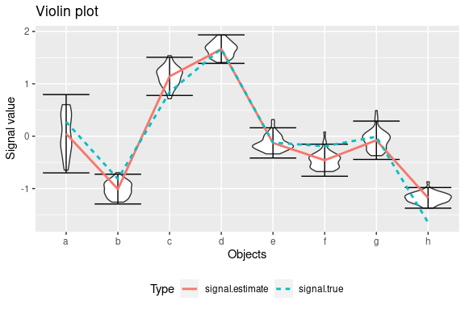

```r
vp <- violinPlot(estimation = estimatedSignal,trueSignal = input$theta.true,title = "Violin plot")
vp
```